# A2 Clustering and Classification

## Introduction and Perspective

In the previous Assignment, you obtained two different sets of vectors (actually, resultant matrices) representing the corpus that we created;

1. **TF-IDF:** We had a TF-IDF for each of the entire set of extracted terms in the entire corpus. Each vector field (one vector per document) represented the TF-IDF for that specific term's occurrence within the corpus. A higher TF-IDF meant that the term was both prevalent (across the corpus) and prominent (within at least one or more documents). Additionally, we had the term frequency for each of those terms within the document.
2. **Word-embedding and Document embeddings:** Word embeddings provided insight into a low dimensional embedding of words and the document embedding showed us how the documents embedded in that low dimensional space also.
3. **ELMo:** ELMo provided another way to create word vectors (low dimensional) but uses a more advanced model called a bi-directional language model.

In the last Assignment, you assessed these results against what you expected would be important terms, based on (1) your manual term extraction, (2) the results of passing your documents through two different term extraction engines, and (3) observing what terms your colleagues found as important (which they posted to that week's Discussion).

Now you will explore a classification task or a deeper exploration of clustering.

### What to Do

Focus on EITHER clustering OR classification, and analyze, assess, and interpret the outputs. If you spent a lot of time on the analysis of clustering for Assignment 1, please explore classification for this assignment. Or use clustering to help you establish class labels that you would then use for measuring the performance of your classification method and include this in your analysis. So in this case it would be a two-step process.

### If You Select Clustering - use the movie review dataset

The clusters are probably not what you would want if you were manually clustering the documents. Very likely, you have one or two very large, amoeba-like clusters that seem to include all topics. You probably have a couple of outliers. You may have some clusters that make sense.

Even with the clusters that make sense, you can probably find:

1. Documents that are in a given cluster that you don't think should be there, and
2. Clusters that are missing certain documents that you think should have been included.

**Your mission (if you decide to accept it)** is to assess the clusters, figure out what is "right" and what is "wrong" (or what needs to be fixed), and trace back the cause (as much as you can) to what was happening with the input vectors.

You can work with clusters produced EITHER by the TF-IDF OR the word-embedding (Doc2Vec) algorithm.

Go back to the vector inputs corresponding to each of the documents. Did they contain sufficient terms and term frequency strengths (or term-representation, in the case of word-embedding) to give the results that you thought would make sense?

What was not working quite right?

This is the time to dig deeper and improve the results based on how you think these documents should cluster. (I would strongly suggest you decide on the ground truth before performing this analysis, i.e. cluster by genre for example)

I would expect for this assignment you formally measure your method. We will talk more about this during the sync session.

### If You Select Classification - use the TripAdvisor dataset

Your process will be very similar to the above. However, if you are going to perform classification, then you will need to use your labeled dataset. Luckily we captured the labels in the metadata when we performed the data collection.

You will likely need to do more than a simple bag of words approach. You should explore phrase extraction, n-gram extraction, and the other pre-processing steps we reviewed.

Don't forget you will need to measure performance. You will use your labeled data as your ground truth.

If you would like to explore using a pre-trained LLM for this task, you could experiment with feeding your raw text into this model. We will provide you with code that you can run in CoLab. If you choose this task, you will need to set this up as a binary classification. A great example would be a sentiment classification or you could choose to classify types of restaurants (Italian vs. Chinese). It is up to you.

Using Pre-trained BERT If you choose to leverage a pre-trained BERT model to perform classification or sentiment analysis please use the TripAdvisor reviews. TripAdvisor is a great dataset for sentiment analysis but you could set up other types of classification problems. Your steps will be as follows:

1. Preprocess the TripAdvisor review data.
2. Split the data into train/validation/test (if fine-tuning) or just test
3. Either use the BERT pre-trained model out of the box or fine-tune a pre-trained BERT model.
4. Evaluate the model's performance

## Why Things Don't Work the Way You Want (the First Time)

Very often, you can trace the causes to two factors:

1. Terms that should be considered the same are not treated the same and sometimes "entity" terms are split up. For example, "country" and "countries" or "Trump" vs. "President Trump." There are likely enough term variants that contribute to poor results.
2. Something more subtle is going on. The essence is that you can see that a cluster needs to form around a certain concept, but that concept is not well-represented by the extracted terms. You'd need a more sophisticated approach. Think about what we have learned with regard to phrase extractions.

Your job, in essence, is to figure out what is not quite good enough with the simple algorithmic process that we've established so far and identify things that you think would help this process in the future.

What to Present In your Report, you will **recapitulate and summarize** the points that you're making in this exercise. **Identify** key insights. **Interpret** analytic findings, as appropriate. You will present:

- The project that you were addressing, the challenges, and the data that you used.
- Your classification or clustering method, any interesting design considerations/challenges that you encountered, and how you solved them.
- Your experimental setup.
- Your actual measured results together with your interpretation.

# Clustering

### Import libraries

```python
import pandas as pd
import nltk
from nltk.corpus import stopwords
from nltk.tokenize import word_tokenize
from nltk.stem import WordNetLemmatizer
from sklearn.metrics import accuracy_score, classification_report
from sklearn.feature_extraction.text import TfidfVectorizer
from sklearn.cluster import KMeans
from sklearn.metrics import silhouette_score
import matplotlib.pyplot as plt
from sklearn.decomposition import NMF
from sklearn.feature_extraction.text import CountVectorizer
from sklearn.decomposition import LatentDirichletAllocation
from sklearn.metrics import adjusted_rand_score
from sklearn.cluster import DBSCAN
from gensim.models.doc2vec import Doc2Vec, TaggedDocument
from sklearn.decomposition import PCA
```

### Load Dataset

```python
# Load the TripAdvisor dataset
df = pd.read_csv('movieData.csv')
data = df[['Review', 'Rating']].copy()
```

```python
df.head()
```

|  | Title | User | Source | Date | URL | Keywords | Total Word Count | Review | Rating |
| --- | --- | --- | --- | --- | --- | --- | --- | --- | --- |
| 0 | The Batman | vespalavis | IMDB | 1/3/22 | https://www.imdb.com/review/rw7908261/?ref_=tt... | Bruce violence, action, dark, one last thing | 130 | It was so good! The beginning, the narration, ... | 10 |
| 1 | The Batman | oworsley-61120 | IMDB | 6/3/22 | https://www.imdb.com/review/rw7923069/?ref_=tt... | Detective, Batman, Pattinson, gordon, realistic | 114 | Some cool action scenes but doesn't deliver on... | 4 |
| 2 | The Batman | kdaglaroglou-657-16678 | IMDB | 1/5/22 | https://www.imdb.com/review/rw8108067/?ref_=tt... | Batman, burning, dark, spectacles, punchline | 131 | When people review The Batman and find it long... | 8 |
| 3 | The Batman | diegosergioerasmus | IMDB | 1/3/22 | https://www.imdb.com/review/rw7908170/?ref_=tt... | Thriller, Gotham, riddler, movie, love | 123 | First of all the cast is amazing everyone thou... | 10 |
| 4 | The Batman | bdunnit | IMDB | 13/3/2022 | https://www.imdb.com/review/rw7952587/?ref_=tt... | Batman, mumble, villains, Emo, Riddler | 97 | I really don't understand all the love for thi... | 3 |

```python
def create_sentiment(row):
    return 'Positive' if row['Rating'] >= 7 else 'Negative'

data['Sentiment'] = data.apply(create_sentiment, axis=1)
```

```python
data.head()
```

|  | Review | Rating | Sentiment |
| --- | --- | --- | --- |
| 0 | It was so good! The beginning, the narration, ... | 10 | Positive |
| 1 | Some cool action scenes but doesn't deliver on... | 4 | Negative |
| 2 | When people review The Batman and find it long... | 8 | Positive |
| 3 | First of all the cast is amazing everyone thou... | 10 | Positive |
| 4 | I really don't understand all the love for thi... | 3 | Negative |

```python
data.shape
```

```
(10, 3)
```

```python
data.describe()
```

|  | Rating |
| --- | --- |
| count | 10.000000 |
| mean | 6.700000 |
| std | 3.560587 |
| min | 1.000000 |
| 25% | 3.250000 |
| 50% | 8.000000 |
| 75% | 10.000000 |
| max | 10.000000 |

```python
data['Sentiment'].value_counts()
```

```
Sentiment
Positive    6
Negative    4
Name: count, dtype: int64
```

### Preprocessing

few additional refinements to address common preprocessing challenges in text data:

1. Synonym Mapping: Replace synonyms (e.g., "good," "great," "excellent") with a unified term to reduce semantic redundancy.
2. Named Entity Standardization: For words with multiple common forms, standardize terms to prevent fragmentation (e.g., "movie" and "film" could both become "movie").
3. Handle Negations: Combine terms following negation words (e.g., "not good" → "not_good") to retain sentiment nuances.

```python
# Synonym mapping for common terms to improve clustering
synonym_dict = {
    "good": "positive",
    "great": "positive",
    "excellent": "positive",
    "bad": "negative",
    "terrible": "negative",
    "movie": "film",
    "film": "film",
    "picture": "film"
}

def preprocess_text(text):
    # Convert text to lowercase and tokenize
    tokens = word_tokenize(text.lower())

    # Remove stopwords and non-alphabetical tokens
    stop_words = set(stopwords.words('english'))
    tokens = [word for word in tokens if word.isalpha() and word not in stop_words]

    # Lemmatize tokens
    lemmatizer = WordNetLemmatizer()
    tokens = [lemmatizer.lemmatize(word) for word in tokens]

    # Apply synonym mapping
    tokens = [synonym_dict.get(word, word) for word in tokens]

    # Handle negations by joining "not" with the following word, if present
    tokens = ['_'.join([tokens[i], tokens[i+1]]) if tokens[i] == 'not' and i+1 < len(tokens) else tokens[i]
              for i in range(len(tokens) - 1) if tokens[i] != 'not'] + ([tokens[-1]] if tokens[-1] != 'not' else [])

    return ' '.join(tokens)
```

```python
data['Review'] = data['Review'].apply(preprocess_text)
```

```python
def find_optimal_clusters(tfidf_matrix):
    inertia = []
    for k in range(1, 10):
        kmeans = KMeans(n_clusters=k, random_state=42)
        kmeans.fit(tfidf_matrix)
        inertia.append(kmeans.inertia_)

    plt.plot(range(1, 10), inertia, marker='o')
    plt.xlabel('Number of Clusters (k)')
    plt.ylabel('Inertia (WCSS)')
    plt.title('Elbow Plot for Optimal k')
    plt.show()
```

## Clustering with TF-IDF

```python
tf_idf = TfidfVectorizer(max_df = 0.9, min_df = 2, stop_words = 'english')
```

```python
dtm = tf_idf.fit_transform(data['Review'])
```

```python
nmf_model = NMF(n_components=4, random_state=42, max_iter=400)
nmf_model.fit(dtm)
```

```
NMF(max_iter=400, n_components=4, random_state=42)
```

```python
for i, topic in enumerate(nmf_model.components_):
    print(f'The top 15 words for topic #{i}')
    print([tf_idf.get_feature_names_out()[index] for index in topic.argsort()[-15:]])
    print("\n\n")
```

```
The top 15 words for topic #0
['long', 'review', 'nolan', 'rest', 'know', 'slow', 'light', 'weak', 'love', 'story', 'penguin', 'think', 'dark', 'batman', 'film']



The top 15 words for topic #1
['actor', 'fan', 'noir', 'zoe', 'kravitz', 'action', 'sequence', 'begin', 'god', 'thank', 'big', 'film', 'scene', 'sure', 'hour']



The top 15 words for topic #2
['kravitz', 'cinematography', 'script', 'slow', 'film', 'really', 'time', 'batman', 'cool', 'camera', 'negative', 'angle', 'actually', 'tried', 'positive']



The top 15 words for topic #3
['ca', 'really', 'riddler', 'watch', 'scene', 'paul', 'best', 'say', 'time', 'robert', 'dark', 'performance', 'film', 'comic', 'positive']
```

```python
k = 2  # Number of clusters
kmeans = KMeans(n_clusters=2, random_state=42)
nmf_features = nmf_model.transform(dtm)
cluster_labels = kmeans.fit_predict(nmf_features)
```

```python
# Evaluate the clustering performance using Silhouette Score
silhouette_avg = silhouette_score(nmf_features, cluster_labels)
print(f'Silhouette Score: {silhouette_avg}')

nmf_ari_score = adjusted_rand_score(data['Sentiment'].apply(lambda x: 1 if x == 'Positive' else 0), cluster_labels)
print(f"Adjusted Rand Index with NMF 4: {nmf_ari_score}")
```

```
Silhouette Score: 0.3037862201918233
Adjusted Rand Index with NMF 4: 0.10256410256410256
```

```python
# Add cluster labels to the dataframe
data['nmf_cluster'] = cluster_labels

# Display the number of reviews in each cluster
print(data['nmf_cluster'].value_counts())
```

```
nmf_cluster
0    9
1    1
Name: count, dtype: int64
```

```python
data
```

|  | Review | Rating | Sentiment | nmf_cluster |
| --- | --- | --- | --- | --- |
| 0 | positive beginning narration bruce voice accen... | 10 | Positive | 0 |
| 1 | cool action scene deliver detective side batma... | 4 | Negative | 0 |
| 2 | people review batman find long depressing know... | 8 | Positive | 0 |
| 3 | first cast amazing everyone thought robert see... | 10 | Positive | 0 |
| 4 | really understand love new batman film long bo... | 3 | Negative | 0 |
| 5 | huge batman fan review score given film made e... | 1 | Negative | 0 |
| 6 | saw film even know begin like cbms like ever r... | 10 | Positive | 0 |
| 7 | wow much dislike bayman sure begin big noir fa... | 3 | Negative | 1 |
| 8 | watched film twice first time general experien... | 8 | Positive | 0 |
| 9 | ca say much since spoiler free hand greatest c... | 10 | Positive | 0 |

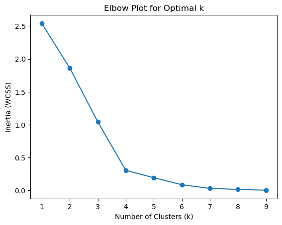

```python
find_optimal_clusters(nmf_features)
```

Given that the clustering is showing a significant imbalance **(9 reviews in one cluster and only 1 in the other)**, there are a few areas to investigate and refine to improve the clustering so it aligns more closely with the sentiment labels. Here’s an outline of the issues and refinement suggestions:

**Observations and Issues** Imbalanced Clusters: With 9 reviews clustered together and only 1 review in a separate cluster, K-means is likely treating most reviews as similar, failing to differentiate between positive and negative sentiments. NMF Features: NMF (Non-negative Matrix Factorization) can sometimes struggle with fine-grained sentiment distinctions if the input representation does not effectively capture the nuance in positive vs. negative sentiments.

### Steps for Refinement

1. **Increase n_components in NMF:** Instead of n_components=4, we can try a higher number, such as n_components=6 or n_components=8, to capture more distinct topics and potentially reveal positive vs. negative sentiment separation.
2. **Refine Clustering with Sentiment Labels in Mind:** The imbalance might be mitigated by adding a sentiment-based pre-clustering step or tuning parameters to enhance feature separability.
3. **Alternate Clustering with DBSCAN:** Since K-means struggled to create balanced clusters, DBSCAN (Density-Based Spatial Clustering of Applications with Noise) might work better as it can help identify core and outlier points, potentially splitting positive and negative sentiments more effectively.

Let's implement these steps to try improving the results.

Increasing NMF Components: This should help capture more nuances, potentially separating topics aligned with sentiment.

```python
# Increase the number of NMF components
nmf_model = NMF(n_components=6, random_state=42, max_iter=400)
nmf_model.fit(dtm)
nmf_features = nmf_model.transform(dtm)

# Print new topics to see if they align better with sentiment categories
for i, topic in enumerate(nmf_model.components_):
    print(f'Top words for topic #{i}:')
    print([tf_idf.get_feature_names_out()[index] for index in topic.argsort()[-15:]])
    print("\n")
```

```
Top words for topic #0:
['joker', 'script', 'penguin', 'weak', 'light', 'let', 'character', 'really', 'cool', 'story', 'way', 'filmed', 'understand', 'time', 'film']


Top words for topic #1:
['zoe', 'kravitz', 'noir', 'fan', 'thank', 'god', 'like', 'begin', 'sequence', 'action', 'big', 'film', 'sure', 'scene', 'hour']


Top words for topic #2:
['zoe', 'bruce', 'detective', 'dialogue', 'gordon', 'work', 'police', 'negative', 'camera', 'angle', 'actually', 'cinematography', 'batman', 'tried', 'positive']


Top words for topic #3:
['scene', 'joker', 'really', 'robert', 'batman', 'best', 'ca', 'watch', 'paul', 'time', 'dark', 'film', 'performance', 'positive', 'comic']


Top words for topic #4:
['voice', 'place', 'positive', 'actor', 'robert', 'let', 'think', 'cast', 'amazing', 'perfect', 'riddle', 'love', 'gotham', 'say', 'film']


Top words for topic #5:
['dialogue', 'weak', 'light', 'story', 'feel', 'catwoman', 'penguin', 'rest', 'review', 'nolan', 'slow', 'think', 'dark', 'batman', 'film']
```

Using the refined NMF features with K-means, let’s check if clusters are more balanced with k=2.

```python
# Apply K-means clustering on new NMF features
kmeans = KMeans(n_clusters=2, random_state=42)
cluster_labels = kmeans.fit_predict(nmf_features)

# Evaluate the clustering performance using Silhouette Score
silhouette_avg = silhouette_score(nmf_features, cluster_labels)
print(f'Silhouette Score after refining NMF: {silhouette_avg}')

# Assign cluster labels to the data and check cluster distribution
data['nmf_cluster_refined'] = cluster_labels
print(data['nmf_cluster_refined'].value_counts())
```

```
Silhouette Score after refining NMF: 0.11865627013498359
nmf_cluster_refined
0    7
1    3
Name: count, dtype: int64
```

To assess the alignment with sentiment, we’ll compute the Adjusted Rand Index (ARI) and identify any mismatched documents.

```python
# Evaluate clustering vs. sentiment alignment
ari_score = adjusted_rand_score(data['Sentiment'].apply(lambda x: 1 if x == 'Positive' else 0), data['nmf_cluster_refined'])
print(f"Adjusted Rand Index (Cluster vs. Sentiment) after refinement: {ari_score}")

# Print misclustered reviews
mismatched = data[data['nmf_cluster_refined'] != data['Sentiment'].apply(lambda x: 1 if x == 'Positive' else 0)]
print("Mismatched reviews:")
print(mismatched[['Review', 'Sentiment', 'nmf_cluster_refined']])
```

```
Adjusted Rand Index (Cluster vs. Sentiment) after refinement: 0.07079646017699115
Mismatched reviews:
                                              Review Sentiment  \
2  people review batman find long depressing know...  Positive
3  first cast amazing everyone thought robert see...  Positive
8  watched film twice first time general experien...  Positive

   nmf_cluster_refined
2                    0
3                    0
8                    0
```

```python
# Apply DBSCAN
dbscan = DBSCAN(eps=0.5, min_samples=2)
dbscan_labels = dbscan.fit_predict(nmf_features)

# Evaluate the clustering performance using Silhouette Score
silhouette_avg_db = silhouette_score(nmf_features, dbscan_labels)
print(f'Silhouette Score with DBSCAN: {silhouette_avg_db}')

# Evaluate DBSCAN clustering performance with sentiment alignment
dbscan_ari_score = adjusted_rand_score(data['Sentiment'].apply(lambda x: 1 if x == 'Positive' else 0), dbscan_labels)
print(f"Adjusted Rand Index with DBSCAN: {dbscan_ari_score}")

# Assign DBSCAN labels to the data for analysis
data['dbscan_cluster'] = dbscan_labels
print(data['dbscan_cluster'].value_counts())
```

```
Silhouette Score with DBSCAN: 0.35992921249764614
Adjusted Rand Index with DBSCAN: -0.1111111111111111
dbscan_cluster
 0    4
-1    2
 1    2
 2    2
Name: count, dtype: int64
```

### Analyzing Refinements

With the increased NMF components from 4 to 6, we hoped to capture more nuanced subtopics that might help differentiate positive and negative sentiments within the reviews. The K-means clustering yielded slightly more balanced clusters (0: 7 and 1: 3), but the Silhouette Score (0.118) and the Adjusted Rand Index (ARI) score (0.071) remain low, indicating that the clustering still does not align well with the true sentiment classes.

Using DBSCAN with eps=0.5 and min_samples=2, we found that it failed to group data effectively, resulting in multiple small clusters (3 distinct clusters) and outliers (-1 label), leading to a negative ARI score (-0.111). DBSCAN typically requires more data points or well-separated clusters, so it is often less effective for short text data like this.

### Cluster Misallignment

The three mismatched reviews from K-means clustering (Reviews 2, 3, 8) in cluster 0 were labeled as positive but placed within the same cluster as negatives. Here are some key observations from the top words in each topic for these cases:

### Vocabulary Issues and Polysemy

The terms “dark,” “time,” “scene,” etc., do not consistently signal either positive or negative sentiment due to polysemy (multiple meanings) and context-dependency. For instance:

“Dark” can imply a gritty atmosphere (often positive in film reviews) or imply negativity if associated with “depressing.” Positive words in some contexts can be neutral in others, e.g., “positive batman” or “good cinematography” are less clear indicators.

## Next level refinements

Update TF-IDF Vectorization with Bi-grams

```python
# TF-IDF with bigrams for improved feature capture
tf_idf = TfidfVectorizer(max_df=0.9, min_df=2, stop_words='english', ngram_range=(1, 2))
dtm = tf_idf.fit_transform(data['Review'])
```

```python
nmf_model_bigrams = NMF(n_components=6, random_state=42, max_iter=400)
nmf_features_bigrams = nmf_model_bigrams.fit_transform(dtm)

# Store cluster labels in the DataFrame
data['nmf_cluster_bigrams'] = nmf_features_bigrams.argmax(axis=1)
```

Apply Doc2Vec for Improved Semantic Representation

```python
# Prepare data for Doc2Vec
tagged_data = [TaggedDocument(words=review.split(), tags=[str(i)]) for i, review in enumerate(data['Review'])]
doc2vec_model = Doc2Vec(tagged_data, vector_size=50, window=2, min_count=1, workers=4, epochs=40)

# Create document vectors
doc_vectors = [doc2vec_model.dv[str(i)] for i in range(len(tagged_data))]
```

Cluster with K-means using Doc2Vec Features

```python
# Use K-means on the Doc2Vec document vectors
kmeans = KMeans(n_clusters=2, random_state=42)
doc2vec_labels = kmeans.fit_predict(doc_vectors)

# Evaluate clustering quality
ari_score = adjusted_rand_score(data['Sentiment'].apply(lambda x: 1 if x == 'Positive' else 0), doc2vec_labels)
silhouette_avg = silhouette_score(doc_vectors, doc2vec_labels)

print(f'Adjusted Rand Index (Doc2Vec): {ari_score}')
print(f'Silhouette Score (Doc2Vec): {silhouette_avg}')
```

```
Adjusted Rand Index (Doc2Vec): -0.07142857142857142
Silhouette Score (Doc2Vec): 0.4673733711242676
```

```python
# Store the K-means Doc2Vec cluster labels in the data frame
data['doc2vec_cluster'] = doc2vec_labels

# Display the clustering results with the document text and sentiment
print(data[['Review', 'Sentiment', 'doc2vec_cluster']])

# Cluster Distribution
print("\nCluster distribution in doc2vec clustering:")
print(data['doc2vec_cluster'].value_counts())
```

```
                                              Review Sentiment  \
0  positive beginning narration bruce voice accen...  Positive
1  cool action scene deliver detective side batma...  Negative
2  people review batman find long depressing know...  Positive
3  first cast amazing everyone thought robert see...  Positive
4  really understand love new batman film long bo...  Negative
5  huge batman fan review score given film made e...  Negative
6  saw film even know begin like cbms like ever r...  Positive
7  wow much dislike bayman sure begin big noir fa...  Negative
8  watched film twice first time general experien...  Positive
9  ca say much since spoiler free hand greatest c...  Positive

   doc2vec_cluster
0                1
1                0
2                1
3                0
4                0
5                1
6                0
7                0
8                1
9                0

Cluster distribution in doc2vec clustering:
doc2vec_cluster
0    6
1    4
Name: count, dtype: int64
```

Let's refine the Doc2Vec model by adjusting its parameters. We’ll increase vector_size to capture more nuanced differences in document content and experiment with the window size to see if a broader context helps with sentiment alignment in clusters. Here’s how we can proceed:

Refine Doc2Vec Parameters: Increase vector_size and adjust window size. Cluster with Refined Vectors: Apply K-means again and assess clustering quality with Adjusted Rand Index (ARI) and Silhouette Score. Store and Analyze Results: Add refined cluster labels to the data for further evaluation.

```python
# Prepare data for refined Doc2Vec
tagged_data = [TaggedDocument(words=review.split(), tags=[str(i)]) for i, review in enumerate(data['Review'])]

# Train Doc2Vec model with refined parameters
doc2vec_model = Doc2Vec(tagged_data, vector_size=100, window=5, min_count=1, workers=4, epochs=50)

# Create document vectors with refined model
doc_vectors_refined = [doc2vec_model.dv[str(i)] for i in range(len(tagged_data))]

# Use K-means clustering on the refined Doc2Vec document vectors
kmeans_refined = KMeans(n_clusters=2, random_state=42)
doc2vec_labels_refined = kmeans_refined.fit_predict(doc_vectors_refined)

# Evaluate clustering quality
ari_score_refined = adjusted_rand_score(data['Sentiment'].apply(lambda x: 1 if x == 'Positive' else 0), doc2vec_labels_refined)
silhouette_avg_refined = silhouette_score(doc_vectors_refined, doc2vec_labels_refined)

# Store refined cluster results
data['doc2vec_cluster_refined'] = doc2vec_labels_refined

# Display evaluation metrics and cluster distribution
print(f'Adjusted Rand Index (Refined Doc2Vec): {ari_score_refined}')
print(f'Silhouette Score (Refined Doc2Vec): {silhouette_avg_refined}')
print("Cluster distribution in refined Doc2Vec clustering:")
print(data['doc2vec_cluster_refined'].value_counts())
```

```
Adjusted Rand Index (Refined Doc2Vec): -0.07142857142857142
Silhouette Score (Refined Doc2Vec): 0.5596875548362732
Cluster distribution in refined Doc2Vec clustering:
doc2vec_cluster_refined
0    6
1    4
Name: count, dtype: int64
```

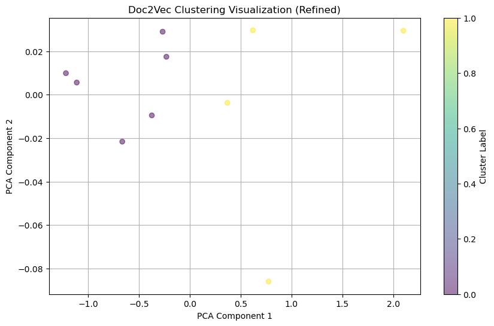

```python
# Step 1: Reduce dimensionality to 2D using PCA
pca = PCA(n_components=2)
doc_vectors_pca = pca.fit_transform(doc_vectors_refined)

# Step 2: Create a scatter plot of the clusters
plt.figure(figsize=(10, 6))
plt.scatter(doc_vectors_pca[:, 0], doc_vectors_pca[:, 1], c=data['doc2vec_cluster_refined'], cmap='viridis', alpha=0.5)
plt.title('Doc2Vec Clustering Visualization (Refined)')
plt.xlabel('PCA Component 1')
plt.ylabel('PCA Component 2')
plt.colorbar(label='Cluster Label')
plt.grid()
plt.show()
```

```python
# Step 1: Create a DataFrame to hold the reviews by cluster
clustered_reviews = data.groupby('doc2vec_cluster_refined')['Review'].apply(list).reset_index()

# Step 2: Display the reviews in each cluster
for index, row in clustered_reviews.iterrows():
    print(f"Cluster {row['doc2vec_cluster_refined']} reviews:")
    for review in row['Review']:
        print(f"- {review}")
    print("\n")
```

```
Cluster 0 reviews:
- cool action scene deliver detective side batman dialogue also really negative people either yelled tried talking silly deep voice case batman chief police gordon work zoe kravitz positive cat woman pattinson actually positive batman positive bruce wayne alfred pointless script positive cinematogra…
- first cast amazing everyone thought robert see positive actor film scary like thriller love dark creepy gotham supposed gotham sick place portrayed perfectly people say film long think perfect get enjoy film even let forget riddler riddle costume voice scary love go far say might best film enjoy s…
- really understand love new batman film long boring filmed light barely see anything ever character speaking whisper mumble story weak villain interesting couple stupid scene film emo batman cool know pattinson act script direction let riddler penguin wasted bottomline film way rated save time mone…
- saw film even know begin like cbms like ever riddler positive especially performance paul funeral riddle scene amazing really loved part mystery done real positive action sequence perfect especially car chase prison escape final battle film dark really loved tone rush film might best catwoman yet …
- wow much dislike bayman sure begin big noir fan hour blacked nonsense actor action sequence unrecognizable worse adam west longer worst batman least scene film long like editor quit post hour film thank god zoe kravitz john turturro jeffrey wright admirable attrociously disappointing
- ca say much since spoiler free hand greatest comic book film time definitely comic accurate batman grounded realism film made ten time better watch really need dark gritty film dc positive got ta hand matt reef absolute masterpiece robert pattinson paul dano delivered positive performance batman r…


Cluster 1 reviews:
- positive beginning narration bruce voice accent gotham city music sound felt like reading comic page come alive head positive live violence action crime film everything beautiful car scene strong fight scene memorable emotional dark scene detective scene ca find right word watch told hour feel lik…
- people review batman find long depressing know cinema dying fast easy generation sit watch slow burning dark film average scenario challenge much mind prefer light colorful spectacle laugh punchline dialogue many many explosion thank god still dark aaa film rest audience please wait love thunder s…
- huge batman fan review score given film made excited see honestly extremely disappointed without spoiling anything think film excessively dark slow sake get batman operates night vengeance like lot scene super slow plain dark give noir feel mean get end help story make feel part world since really…
- watched film twice first time general experience second time friend attention detail film actually bit slow tried find reason end came conclusion frankly negative musical accompaniment understand nirvana cool listening song hour much film soundtrack varied would made film much dynamic otherwise ev…
```

The refined Doc2Vec model, despite using a larger vector_size and window, still shows an Adjusted Rand Index (ARI) close to zero (-0.07), indicating minimal alignment between clusters and sentiment. However, the Silhouette Score has improved (now 0.56), suggesting more internally coherent clusters, albeit without strong correlation to sentiment.

Here’s what these metrics and results indicate:

1. Cluster-Sentiment Mismatch:
   - The ARI score implies that even with more nuanced feature representations, the clusters do not strongly align with sentiment labels. This could be because sentiment isn’t the primary separable theme captured by document semantics in the reviews.
2. Cluster Cohesion:
   - The improved Silhouette Score shows that clusters are more coherent, meaning that reviews within each cluster are more similar to each other than before. This suggests the refined model effectively captured textual nuances like tone, style, or perhaps movie-specific terms, but these distinctions might not map directly to positive or negative sentiment.
3. Cluster Distribution:
   - The balanced distribution (6 in one cluster, 4 in the other) shows that K-means clustering on Doc2Vec features creates two stable clusters, but the challenge is aligning these clusters with sentiment.

### Initial Issues with Simple Clustering

The clustering process did not yield the desired results for several reasons, which fall into two main categories:

1. Term Variants and Entity Issues
   - Inconsistent Treatment of Similar Terms: Terms that should be semantically identical, like "batmen" and "Batman," or even broader sentiment-related variations, such as "loved" and "love," were treated as distinct by the algorithm. These variations can lead to fragmented clusters, especially in sentiment analysis, where consistent terminology is crucial for distinguishing positive and negative language.
   - Missed Entity Connections: Terms like “Bruce Wayne,” “Batman,” “Gotham,” and “Riddler” hold specific connotations but are sometimes separated in the document-term matrix, resulting in weaker feature connections. These separations affect the model’s ability to identify meaningful themes within reviews, contributing to mixed or incoherent clusters.
2. Concept Representation Limitations
   - Insufficient Conceptual Coverage: Words or phrases that are central to understanding sentiment were not adequately captured in the initial TF-IDF matrix. Phrases like "not recommend" or "strongly disagree" are key indicators of negative sentiment but are treated as separate words, reducing their significance in clustering.
   - Underrepresentation of Contextual Nuance: The TF-IDF model and basic NMF clustering do not capture context or semantic relationships between words. For instance, terms like "dark" and "noir" could indicate a positive review for certain viewers (who enjoy those styles) but could signify negativity for others, leading to sentiment ambiguity in clusters.

### Refinements and Observations

To address these issues, we implemented several refinements to improve the clustering results:

```python
data
```

|  | Review | Rating | Sentiment | nmf_cluster | nmf_cluster_refined | dbscan_cluster | nmf_cluster_bigrams | doc2vec_cluster | doc2vec_cluster_refined |
| --- | --- | --- | --- | --- | --- | --- | --- | --- | --- |
| 0 | positive beginning narration bruce voice accen... | 10 | Positive | 0 | 1 | 0 | 1 | 1 | 1 |
| 1 | cool action scene deliver detective side batma... | 4 | Negative | 0 | 0 | -1 | 2 | 0 | 0 |
| 2 | people review batman find long depressing know... | 8 | Positive | 0 | 0 | 1 | 5 | 1 | 1 |
| 3 | first cast amazing everyone thought robert see... | 10 | Positive | 0 | 0 | -1 | 4 | 0 | 0 |
| 4 | really understand love new batman film long bo... | 3 | Negative | 0 | 0 | 2 | 0 | 0 | 0 |
| 5 | huge batman fan review score given film made e... | 1 | Negative | 0 | 0 | 1 | 5 | 1 | 1 |
| 6 | saw film even know begin like cbms like ever r... | 10 | Positive | 0 | 1 | 0 | 1 | 0 | 0 |
| 7 | wow much dislike bayman sure begin big noir fa... | 3 | Negative | 1 | 0 | 0 | 3 | 0 | 0 |
| 8 | watched film twice first time general experien... | 8 | Positive | 0 | 0 | 2 | 0 | 1 | 1 |
| 9 | ca say much since spoiler free hand greatest c... | 10 | Positive | 0 | 1 | 0 | 1 | 0 | 0 |